# Estudios de Informática, Multimedia y Telecomunicaciones

# Mineria de dades: PRA1 - Selecció i preparació d’un joc de dades

Autor: Nom estudiant

Abril 2021

# 1 Introducció

## 1.1 Presentació

Aquesta pràctica cobreix de forma transversal la assignatura.

Les Pràctiques 1 i 2 de la assignatura es plantegen d’una forma conjunta de forma que la Pràctica 2 serà continuació de la 1.

L’objectiu global de les dues pràctiques consisteix en seleccionar un o varis jocs de dades, realitzar les tasques de **preparació i anàlisi exploratori** amb l’objectiu de disposar de dades a punt per a **aplicar algoritmes** de clustering, associació i classificació.

## 1.2 Competències

Les competències que es treballen en aquesta prova són:

- Ús i aplicació de les TIC en l’àmbit acadèmic i professional.
- Capacitat per innovar i generar noves idees.
- Capacitat per avaluar solucions tecnològiques i elaborar propostes de projectes tenint en compte els recursos, les alternatives disponibles i les condicions de mercat.
- Conèixer les tecnologies de comunicacions actuals i emergents així com saber-les aplicar convenientment per dissenyar i desenvolupar solucions basades en sistemes i tecnologies de la informació.
- Aplicació de les tècniques específiques d’enginyeria de programari en les diferents etapes del cicle de vida d’un projecte.
- Capacitat per aplicar les tècniques específiques de tractament, emmagatzematge i administració de dades.
- Capacitat per proposar i avaluar diferents alternatives tecnològiques per a resoldre un problema concret.

## 1.3 Objectius

La correcta assimilació de tots els aspectes treballats durant el semestre. En aquesta pràctica abordem un cas real de mineria de dades on hem de posar en joc tots els conceptes treballats. Cal treballar tot el cicle de vida del projecte. Des del objectiu de el projecte fins a la implementació de el coneixement trobat passant per la preparació, neteja de les dades, coneixement de les dades, generació de el model, interpretació i avaluació.

## 1.4 Descripció de la PRA a realitzar

## 1.5 Recursos Bàsics

Material docent proporcionat per la UOC.

## 1.6 Criteris de valoració

**Exercicis pràctics**

Per a totes les PRA és **necessari documentar** en cada apartat de l’exercici pràctic qué s’ha fet i com s’ha fet.

## 1.7 Format i data de lliurament PRA_1

El format de lliurament és: usernameestudiant-PRAn.html/doc/docx/odt/pdf  
Data de lliurament: 05/05/2021  
S’ha de lliurar la PRA_1 a la bústia de lliuraments de l’aula.

## 1.8 Nota: Propietat intel·lectual

> Sovint és inevitable, a l’produir una obra multimèdia, fer ús de recursos creats per terceres persones. És per tant comprensible fer-ho en el marc d’una pràctica dels estudis d’Informàtica, Multimèdia i Telecomunicació de la UOC, sempre que això es documenti clarament i no suposi plagi en la pràctica.

> Per tant, a l’presentar una pràctica que faci ús de recursos aliens, s’ha de presentar juntament amb ella un document en què es detallin tots ells, especificant el nom de cada recurs, el seu autor, el lloc on es va obtenir i el seu estatus legal : si l’obra està protegida pel copyright o s’acull a alguna altra llicència d’ús (Creative Commons, llicència GNU, GPL …). L’estudiant haurà de assegurar-se que la llicència no impedeix específicament seu ús en el marc de la pràctica. En cas de no trobar la informació corresponent haurà d’assumir que l’obra està protegida per copyright.

> Haureu, a més, adjuntar els fitxers originals quan les obres utilitzades siguin digitals, i el seu codi font si correspon.

# 2 Enunciat

Tot estudi analític ha de néixer d’una necessitat per part del negoci o d’una voluntat de dotar-lo d’un coneixement i contingut en les dades que només podrem obtenir a través d’una col·lecció de bones pràctiques basades en la Mineria de Dades.

El món de l’analítica de dades es sustenta en 3 eixos:

1. Un d’ells és el profund **coneixement** que hauríem de tenir **del negoci** a què tractem de donar respostes mitjançant els estudis analítics.
2. L’altre gran eix és sens dubte les **capacitats analítiques** que siguem capaços de desplegar i en aquest sentit, les dues pràctiques d’aquesta assignatura pretenen que l’estudiant realitzi un recorregut sòlid per aquest segon eix.
3. El tercer eix són els **Dades**. Les necessitats del negoci s’han de concretar amb preguntes analítiques que al seu torn siguin viables respondre a partir de les dades de què disposem. La tasca d’analitzar les dades és sens dubte important, però la tasca d’identificar-los i obtenir-los ha de ser per a un analista un repte permanent.

Com **primera part** de l’estudi analític que ens disposem a realitzar, es demana a l’estudiant que completi els següents passos:

1. Plantejar un problema d’analítica de dades detallant-ne els objectius analítics i explica una metodologia per a resoldre’ls d’acord amb lo practicat en les PAC anteriors i també d’acord a lo que s’ha aprés en el material didàctic.
2. Seleccionar un joc de dades i justificar la seva elecció. El joc de dades haurà de tenir capacitats perquè se li puguin aplicar algoritmes supervisats, algoritmes no supervisats i regles d’associació. També haurà d’estar alineat amb el problema analític plantejat en el pas anterior.  
   El joc de dades ha de tenir com a mínim 100 observacions i ha de ser diferent de l’utilitzat en les PAC anteriors.
3. Realitzar una anàlisi exploratòria de el joc de dades seleccionat.
4. Realitzar tasques de neteja i condicionat per poder ser usat en processos de modelatge.
5. Realitzar mètodes de discretització
6. Aplicar un estudi PCA sobre el joc de dades. Tot i no estar explicat en el material didàctic, es valorarà si en lloc de PCA investigueu pel vostre compte i apliqueu SVD (Single Value Decomposition).

# 3 Rúbrica

- 30%. Es planteja un problema propi de mineria de dades, se’n detallen els objectius analítics i s’explica detalladament la metodologia per a donar-los solució.
- 10%. Justificació de l’elecció del joc de dades on es detalla el potencial analític que s’intueix. L’estudiant haurà de visitar els següents portals de dades obertes per a seleccionar el seu joc de dades:
  - [Datos.gob.es](https://datos.gob.es/es/catalogo?q=&frequency=%7B%22type%22%3A+%22months%22%2C+%22value%22%3A+%221%22%7D&sort=score+desc%2C+metadata_modified+desc)
  - [UCI Machine Learning](https://archive.ics.uci.edu/ml/datasets.php)
  - [Datasets Wikipedia](https://en.wikipedia.org/wiki/List_of_datasets_for_machine-learning_research)
  - [Datos abierto Madrid](https://datos.madrid.es/portal/site/egob/)
  - [Datos abiertos Barcelona](https://opendata-ajuntament.barcelona.cat/ca/)
  - [London Datastore](https://data.london.gov.uk/)
  - [NYC OpenData](https://opendata.cityofnewyork.us/)
- 20%. Informació extreta de l’anàlisi exploratòria. Distribucions, correlacions, anomalies, …
- 20%. Explicació clara de qualsevol tasca de neteja o condicionat que es realitza. Justificant el motiu i esmentant els avantatges de l’acció presa.
- 20%. Es realitza un procés de PCA o SVD on s’aprecia mitjançant explicacions i comentaris que l’estudiant entén tots els passos i es Scomenta extensament el resultat final obtingut.

# 4 Recursos de programació

- Incloem en aquest apartat una llista de recursos de programació per a mineria de dades on podreu trobar exemples, idees i inspiració:
  - [Material addicional del llibre: Minería de datos Modelos y Algoritmos](http://oer.uoc.edu/libroMD/)
  - [Espai de recursos UOC per a ciència de dades](http://datascience.recursos.uoc.edu/)
  - [Cercador de codi R](https://rseek.org/)
  - [Col·lecció de cheatsheets en R](https://rstudio.com/resources/cheatsheets/)

# 5 Estudi Analític

## 5.1 - Plantejament del problema analític i justificació de la selecció de dades.

El problema analític que volem plantejar en aquest estudi, inicialment no es trobava focalitzat en cap àmbit concret, simplement tenia la intenció de treballar amb dades de la ciutat de Barcelona, i que mitjançant aquestes poder extreure nous punts de vista i nova informació no fàcilment visible.

El principal interès d’aquesta investigació era la de poder ajudar a les institucions a prendre decisions que afavorissin a la ciutadania. És per això que quan vaig observar que hi havia una Dataset que disposava de la informació de les persones aturades de Barcelona, i a la vegada, separada per barris, em vaig decidir per aquest. Crec que l’anàlisi d’aquestes dades pot aportar noves solucions per a les persones que no disposen d’una feina.

## 5.2 - Anàlisi exploratiu de les dades.

Les dades seleccionades i que farem servir per a realitzar aquest estudi analític es troben disponible a la plataforma Open Data BCN mitjançant el següent enllaç.

[https://opendata-ajuntament.barcelona.cat/data/ca/dataset/est-atur-pes](https://opendata-ajuntament.barcelona.cat/data/ca/dataset/est-atur-pesx)

L’Open Data BCN es tracta d’un portal que ofereix dades de caràcter públic de diferents àmbits, sectors i interessos relacionades amb la ciutat de Barcelona. Aquesta plataforma ens aporta dades fàcilment descarregables en diferents tipus de fitxers i formats per a ser utilitzades. En el nostre cas ens trobem que les dades de l’atur de Barcelona es troben dividies en fitxers CSV que representen un any natural entre el 2012 i l’actual 2021. La granularitat de les dades en el seu interior serà mensual per a cada un dels barris de la ciutat de Barcelona.

A continuació ens mostrem de forma visual quins són els paràmetres rebuts al Data Set, que signifiquen i de quin tipus són.

| Variable | Description | Type |
| --- | --- | --- |
| Any | Any del registre | Numèric |
| Mes | Mes del registre | Numeric |
| CodiDistrict | ID del districte | Numeric |
| NomDistrict | Nom del districte | String |
| CodiBarri | ID del barri | Numeric |
| NomBarri | Nom del barri | String |
| Poblacio16_64anys | Població entre 16 i 64 anys | Numeric |
| PesAtur | Percentatge atur dins la població d’entre 16 i 64 anys | Numeric |

Seguidament passarem a carregar les llibreries que utilitzarem al llarg de l’estudi i també carregarem les dades.

Càrrega de les llibreries.

```r
# https://cran.r-project.org/web/packages/ggplot2/index.html
if (!require('ggplot2')) install.packages('ggplot2'); library('ggplot2')

# https://cran.r-project.org/web/packages/dplyr/index.html
if (!require('dplyr')) install.packages('dplyr'); library('dplyr')

if(!require(cluster)) install.packages(cluster);library(cluster)
if(!require(MVA)) install.packages("MVA"); library(MVA)
if(!require(tidyr)) install.packages("tidyr");library(tidyr)
if(!require(cluster)) install.packages("cluster"); library(cluster)
if(!require(plyr)) install.packages("plyr"); library(plyr)
if(!require(readr)) install.packages("readr"); library(readr)
```

Càrrega de les dades.

```r
#https://datascienceplus.com/how-to-import-multiple-csv-files-simultaneously-in-r-and-create-a-data-frame/

#All files
mycsvfiles = list.files(pattern="*.csv", full.names=TRUE)
mycsvfiles
```

```
##  [1] "./2012_atur.csv" "./2013_atur.csv" "./2014_atur.csv" "./2015_atur.csv"
##  [5] "./2016_atur.csv" "./2017_atur.csv" "./2018_atur.csv" "./2019_atur.csv"
##  [9] "./2020_atur.csv" "./2021_atur.csv"
```

```r
datafromcsv = ldply(mycsvfiles, read_csv)
colnames(datafromcsv) <- c("Any", "Mes", "CodiDistricte", "NomDistricte", "CodiBarri", "NomBarri", "Poblacio16_64anys", "PesAtur")

#Only Atur2019
atur2019<-read.csv("2019_atur.csv", header = T, sep=",")
colnames(atur2019) <- c("Any", "Mes", "CodiDistricte", "NomDistricte", "CodiBarri", "NomBarri", "Poblacio16_64anys", "PesAtur")
```

Podem observar que per un costat carreguem les dades de l’atur del 2019, mentre que per l’altre, carreguem totes les dades que trobem en tots els fitxers CSV en el nostre directori. Això és degut al fet que desitgem crear un Dataset que contingui totes les dades de l’atur per barri a la ciutat de Barcelona contingut entre els anys 2012 i 2021, mentre que en l’altre cas volem les dades concretes d’un any per poder fer un estudi més concret en un període més curt de temps.

A continuació mostrem l’estructura de les dades i algunes estadístiques bàsiques d’aquestes, així com una petita mostra dels valors.

```r
str(datafromcsv)
```

```
## 'data.frame':    8103 obs. of  8 variables:
##  $ Any              : num  2012 2012 2012 2012 2012 ...
##  $ Mes              : num  1 1 1 1 1 1 1 1 1 1 ...
##  $ CodiDistricte    : num  1 1 1 1 2 2 2 2 2 2 ...
##  $ NomDistricte     : chr  "Ciutat Vella" "Ciutat Vella" "Ciutat Vella" "Ciutat Vella" ...
##  $ CodiBarri        : num  1 2 3 4 5 6 7 8 9 10 ...
##  $ NomBarri         : chr  "el Raval" "el Barri Gòtic" "la Barceloneta" "Sant Pere, Santa Caterina i la Ribera" ...
##  $ Poblacio16_64anys: num  36365 12882 10857 16714 21782 ...
##  $ PesAtur          : num  13.9 11.7 14 12.6 9.1 9.4 7.8 9 9.1 10.2 ...
```

```r
summary(datafromcsv)
```

```
##       Any            Mes         CodiDistricte    NomDistricte
##  Min.   :2012   Min.   : 1.000   Min.   : 1.000   Length:8103
##  1st Qu.:2014   1st Qu.: 3.000   1st Qu.: 4.000   Class :character
##  Median :2016   Median : 6.000   Median : 7.000   Mode  :character
##  Mean   :2016   Mean   : 6.378   Mean   : 6.247
##  3rd Qu.:2018   3rd Qu.: 9.000   3rd Qu.: 8.000
##  Max.   :2021   Max.   :12.000   Max.   :10.000
##    CodiBarri    NomBarri         Poblacio16_64anys    PesAtur
##  Min.   : 1   Length:8103        Min.   :  257     Min.   : 2.700
##  1st Qu.:19   Class :character   1st Qu.: 6928     1st Qu.: 6.700
##  Median :37   Mode  :character   Median :13873     Median : 8.600
##  Mean   :37                      Mean   :14552     Mean   : 8.987
##  3rd Qu.:55                      3rd Qu.:19909     3rd Qu.:10.800
##  Max.   :73                      Max.   :38628     Max.   :21.800
```

```r
head(datafromcsv)
```

```
##    Any Mes CodiDistricte NomDistricte CodiBarri
## 1 2012   1             1 Ciutat Vella         1
## 2 2012   1             1 Ciutat Vella         2
## 3 2012   1             1 Ciutat Vella         3
## 4 2012   1             1 Ciutat Vella         4
## 5 2012   1             2     Eixample         5
## 6 2012   1             2     Eixample         6
##                                NomBarri Poblacio16_64anys PesAtur
## 1                              el Raval             36365    13.9
## 2                        el Barri Gòtic             12882    11.7
## 3                        la Barceloneta             10857    14.0
## 4 Sant Pere, Santa Caterina i la Ribera             16714    12.6
## 5                         el Fort Pienc             21782     9.1
## 6                    la Sagrada Família             34838     9.4
```

## 5.3 - Tasques de neteja.

En aquest apartat ens focalitzarem en determinar quins són els atributs que són realment necessaris per a executar el nostre projecte.

Algunes vegades podem trobar que certs paràmetres són redundants entre ells, és a dir, que ens aporten la mateixa informació, i per tant no té sentit mantenir-los. En el nostre cas ens trobem que els camps *NomBarri* i *NomDistricte* són redundants, ja que ens aporten una informació que de cara a l’estudi és irrellevant, així com que aquests ja disposen d’un identificador ( *CodiBarri* i *CodiDistricte* respectivament) que fan aquesta funció. A la vegada, aquests atributs són de tipus numèrics, fet que ens facilitaran la feina a l’hora de treballar i no haurem de realitzar cap transformació dels paràmetres en format de caràcters a numèric.

Filtratge de les dades per quedar-nos amb els valors numèrics que ens interessen.

```r
#Grab only numeric values
#src: https://datascienceplus.com/how-to-import-multiple-csv-files-simultaneously-in-r-and-create-a-data-frame/
numericData <- datafromcsv %>% select(is.numeric)
numericData2019 <- atur2019 %>% select(is.numeric)

#Get the number of fields
numericNCols = ncol(numericData)
numericNCols
```

```
## [1] 6
```

```r
#Get the fields
numericFields = colnames(numericData)
numericFields
```

```
## [1] "Any"               "Mes"               "CodiDistricte"
## [4] "CodiBarri"         "Poblacio16_64anys" "PesAtur"
```

```r
#Get the number of entries
numericRows = dim(numericData)[1]
numericRows
```

```
## [1] 8103
```

Un cop obtingut el DataFrame amb els paràmetres exclusivament necessari, comprovarem si tenim valors buits.

```r
#Get NA fields
colSums(is.na(numericData))
```

```
##               Any               Mes     CodiDistricte         CodiBarri
##                 0                 0                 0                 0
## Poblacio16_64anys           PesAtur
##                 0                 0
```

```r
colSums(is.na(numericData2019))
```

```
##               Any               Mes     CodiDistricte         CodiBarri
##                 0                 0                 0                 0
## Poblacio16_64anys           PesAtur
##                 0                 0
```

Un cop hem comprovat que no disposem de valors buits, podrem passar al següent apartat de l’anàlisi.

## 5.4 - Anàlisi de les dades

Un primer pas per on podem començar aplicant a les nostres dades són **mètodes d’agregació**. D’aquesta manera podrem tenir una primera visió de dividir i detectar els objectes semblants dins del nostre domini o conjunt d’observacions.

És per això que té molt de sentit aplicar un criteri com el de *Calinski-Harabasz* per tal que mitjançant l’execució de l’algorisme *kmeans* sobre el nostre conjunt de dades, ens determini quin podria ser el valor **k** adient per tal de realitzar la nostra clusterització de dades.

Carreguem les llibreries per a elaborar aquesta anàlisi.

```r
if(!require(fpc)) install.packages(fpc); library(fpc)
if(!require(class)) install.packages(class); library(class)
```

A continuació determinem que el rang sobre el qual volem trobar el millor valor **k** és entre 1 i 73, on 73 correspon el nombre de barris que disposem dins de la ciutat de Barcelona.

```r
#Calinski-Harabasz criterion computation
fit_ch  <- kmeansruns(numericData2019, krange = 1:73, criterion = "ch")
print(fit_ch$bestk)
```

```
## [1] 73
```

*Warning: Aquest valor és variable degut al fet que ens trobem executant l’algorisme kmeans que té un factor aleatori.*

Tot i el que hem matisat anteriorment, el valor que més s’ha repetit durant el llarg de les execucions és 73. Així doncs, podem determinar que el comportament de semblança es troba bastant lligat a la quantitat dels barris, és a dir, a cada un dels barris.

A continuació mostrem de forma visual les relacions entre parells de característiques, que trobem en els nostres clústers, forçant que el nombre de clústers és 73, el valor majoritari respecte el criteri de *Calinski-Harabasz*.

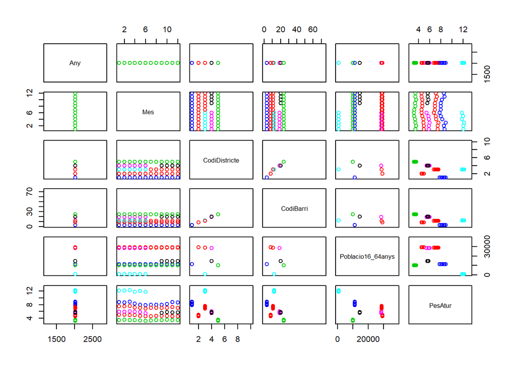

```r
#cl3 <- kmeans(numericData2019, fit_ch$bestk) #Also a possible way to do it

cl3 <- kmeans(numericData2019, 73)
with(numericData2019, pairs(numericData2019, col=c(1:6)[cl3$cluster]))
```

És a través d’aquest primer gràfic que podem començar a trobar i a veure punts interessants d’anàlisi i relació.

### 5.4.1 - Proporció de les persones aturades

```r
#Filter the value with 'CodiDistricte' equals 1
districte1 <- numericData2019 %>% filter(CodiDistricte == 1)

#Computation of the mean value for the fields 'Poblacio16_64anys' and 'PesAtur'
meanPoblacio1 <- mean(numericData2019$Poblacio16_64anys)
meanAtur1 <- mean(numericData2019$PesAtur)

#Graph
#ggplot(data = numericData2019, aes(y=meanPoblacio1, fill=meanAtur1)) + geom_bar(position="fill")+facet_wrap(~CodiDistricte) #not working :(
```

### 5.4.2 - Fluctuació de l’atur

Un altre element que podem visualitzar de forma clara i que pot ser molt interessant de tractar, és la fluctuació de l’atur al llarg del temps. A través d’aquesta anàlisi podem veure quin és el segment de valors sobre el que s’ha anat movent l’atur en un període concret en un barri i/o districte determinat.

Aquest anàlisi el podem realitzar a diferents escales. És a dir, aquest estudi el podem realitzar més o menys focalitzat segons ens interessi per a un cas concret. Exemples possibles d’anàlisi en les dimensions temporals i espacials:

- Anàlisi per barris.
- Anàlisi per districtes.
- Anàlisi anual.
- Anàlisi mensual.

A continuació podrem visualitzar la representació gràfica els segments sobre els quals es mou l’atur a la ciutat de Barcelona entre els anys 2012 i 2021, fent una separació espacial pels 10 districtes.

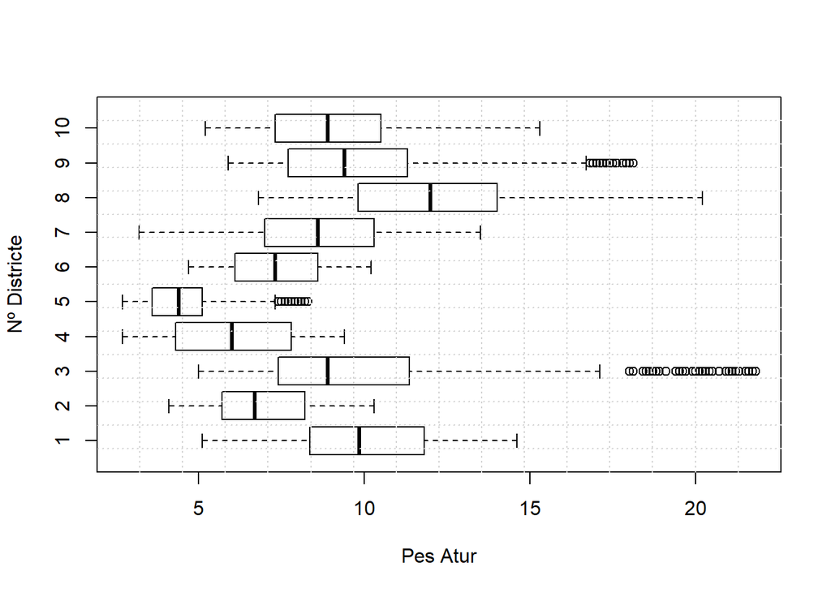

```r
b <- boxplot(PesAtur ~ CodiDistricte, data = numericData, xlab = "Pes Atur", ylab = "Nº Districte", horizontal=TRUE)
grid(nx=16, ny=16)
```

### 5.4.4 - Passos futurs

L’evolució d’aquest estudi seria molt interessant de què fos aprofitat a llarg termini. És per això que un dels passos futurs a realitzar en aquest estudi, és el d’aplicar mètodes de regressió i predictius, per tal que donades unes quantitats de població, puguem anticipar quins seran els valors d’atur a cada un dels punts de Barcelona. L’ús d’aquestes prediccions podria ser la implementació de polítiques de caràcter social, per tal d’ajudar de forma més focalitzada a aquestes persones que no disposen de feina.